# Assignment_2_6783

### Group Members:

[output not shown]

```python
import matplotlib.pyplot as plt
import numpy as np
import pandas as pd
import seaborn as sns
from sklearn.linear_model import Ridge, RidgeCV, Lasso, LassoCV
from sklearn.linear_model import LinearRegression as lm
from sklearn.preprocessing import normalize

from sklearn.metrics import mean_squared_error
from sklearn.model_selection import train_test_split

from sklearn.decomposition import PCA
from sklearn.preprocessing import StandardScaler
from sklearn.pipeline import Pipeline

from tqdm import tqdm

import warnings
from sklearn.exceptions import ConvergenceWarning
warnings.filterwarnings("ignore", category=ConvergenceWarning)
```

```python
myData = pd.read_csv("Coding2_Data0.csv")
names = myData.columns
Y = myData[['Y']].to_numpy()
X = myData.drop(['Y'], axis = 1).to_numpy()
myData
```

|  | V1 | V2 | V3 | V4 | V5 | V6 | V7 | V8 | V9 | V10 | V11 | V12 | V13 | Y |
| --- | --- | --- | --- | --- | --- | --- | --- | --- | --- | --- | --- | --- | --- | --- |
| 0 | -5.064036 | 1.8 | 0.837248 | 0 | -0.619897 | 1.883275 | 3.432567 | 1.408545 | 0.000000 | 5.690359 | 0.454865 | 3.9690 | 2.231591 | 3.178054 |
| 1 | -3.600502 | 0.0 | 1.955860 | 0 | -0.757153 | 1.859574 | 5.529585 | 1.602836 | 0.693147 | 5.488938 | 1.236450 | 3.9690 | 3.023243 | 3.072693 |
| 2 | -3.601235 | 0.0 | 1.955860 | 0 | -0.757153 | 1.971996 | 2.918119 | 1.602836 | 0.693147 | 5.488938 | 1.236450 | 3.9283 | 2.007486 | 3.546740 |
| 3 | -3.430523 | 0.0 | 0.779325 | 0 | -0.780886 | 1.945624 | 1.419592 | 1.802073 | 1.098612 | 5.402677 | 1.772241 | 3.9463 | 1.714643 | 3.508556 |
| 4 | -2.672924 | 0.0 | 0.779325 | 0 | -0.780886 | 1.966693 | 2.162710 | 1.802073 | 1.098612 | 5.402677 | 1.772241 | 3.9690 | 2.308679 | 3.589059 |
| ... | ... | ... | ... | ... | ... | ... | ... | ... | ... | ... | ... | ... | ... | ... |
| 501 | -2.770511 | 0.0 | 2.479056 | 0 | -0.556870 | 1.886008 | 3.969128 | 0.907694 | 0.000000 | 5.609472 | 4.447067 | 3.9199 | 3.109662 | 3.109061 |
| 502 | -3.095111 | 0.0 | 2.479056 | 0 | -0.556870 | 1.811562 | 5.152149 | 0.827460 | 0.000000 | 5.609472 | 4.447067 | 3.9690 | 3.013304 | 3.025291 |
| 503 | -2.800824 | 0.0 | 2.479056 | 0 | -0.556870 | 1.942476 | 7.899571 | 0.773574 | 0.000000 | 5.609472 | 4.447067 | 3.9690 | 2.374868 | 3.173878 |
| 504 | -2.211009 | 0.0 | 2.479056 | 0 | -0.556870 | 1.916040 | 7.535788 | 0.870833 | 0.000000 | 5.609472 | 4.447067 | 3.9345 | 2.545584 | 3.091042 |
| 505 | -3.048922 | 0.0 | 2.479056 | 0 | -0.556870 | 1.796747 | 5.868517 | 0.918289 | 0.000000 | 5.609472 | 4.447067 | 3.9690 | 2.807134 | 2.476538 |

506 rows × 14 columns

```python
X.shape, len(Y)
```

```
((506, 13), 506)
```

#### Part I: Implement Lasso

##### One-variable Lasso

First, write a function one_var_lasso that takes the following inputs:

$$v = (v1, . . . , vn)^t , z = (z1, . . . , zn)^t , λ > 0$$

and solves the following one-variable Lasso problem:

$$\min_{b} \frac{1}{2n}\sum_{i=1}^{n} (vi − bzi)^2 + λ|b| = \min_{b}\frac{1}{2n} ||v − b · zk^2|| + λ|b|$$.

Check the [derivation] for one-variable lasso.

#### The CD Algorithm

Next, write your own function MyLasso to implement the Coordinate Descent (CD) algorithm by repeatedly calling one_var_lasso. In the CD algorithm, at each iteration, we solve a one-variable Lasso problem for βj while holding the other (p-1) coefficients at their current values:

$$\min_{\beta j} \frac{1}{2n}\sum_{i=1}^{n} (yi − \sum_{k!=j}^{}x_{ik}{\beta}_{k}-x_{ij}{\beta}_{j})^2 + λ\sum_{k!=j}^{}|\beta_{k}|+λ^{}|\beta_{j}|$$

which is equivalent to solving the following one-variable Lasso problem $$\min_{\beta j} \frac{1}{2n}\sum_{i=1}^{n} (vi − x_{ij}{\beta}_{j})^2 + λ|\beta_{j}| , v_{i} = y_{i}-\sum_{k!=j}x{}_{ik}{\beta}_{k}$$

#### Test Your Function

Download the data set Coding2_Data0.csv. The data set has 13 predictors, V1 to V13, and one response vector Y. Test your function MyLasso on the data set Coding2_Data0.csv with a specific lambda sequence. Refer to the sample code in R/Python for the specified lambda sequence. 1 Compare the estimated Lasso coefficients from your function with those provided in Coding2_lasso_coefs.csv. The maximum difference between the two coefficient matrices should be less than 0.005. Refer to the sample code for instructions on how to read in the coefficients from Coding2_lasso_coefs.csv. The coefficients in Coding2_lasso_coefs.csv are Lasso coefficients returned by R with the option standardized = TRUE, so ensure that the X features are centered and scaled in your MyLasso function..

```python
def one_var_lasso(residual, x, lam):
    a = np.dot(residual.T, x) / np.dot(x.T, x)
    eta = (2 * len(residual) * lam) / np.dot(x.T, x)

    if a > eta / 2:
        beta = a - eta / 2
    elif a < -eta / 2:
        beta = a + eta / 2
    else:
        beta = 0

    return beta
```

```python
def MyLasso(X, y, lam_seq, maxit = 100):

    # Input
    # X: n-by-p design matrix without the intercept
    # y: n-by-1 response vector
    # lam.seq: sequence of lambda values (arranged from large to small)
    # maxit: number of updates for each lambda

    # Output
    # B: a (p+1)-by-len(lam.seq) coefficient matrix
    #    with the first row being the intercept sequence


    n, p = X.shape
    nlam = len(lam_seq)
    B = np.zeros((p+1, nlam))

    ##############################
    # YOUR CODE:
    # (1) newX = Standardizad X;
    # (2) Record the centers and scales used in (1)
    ##############################

    # 標準化 X
    newX = (X - X.mean(axis=0)) / X.std(axis=0)


    # Initilize coef vector b and residual vector r
    b = np.zeros(p)
    r = y


    # Triple nested loop
    for m in range(nlam):
        for step in range(maxit):
            for j in range(p):
                X_j = newX[:, j].reshape(-1, 1)  # 確保 X_j 是列向量
                r = r + X_j * b[j]

                # one_var_lasso 預期的應該是單一數值，檢查是否需要提取單一元素
                if r.ndim > 0:  # 如果 r 是多維陣列
                    r_scalar = r.flatten()  # 把 r 攤平為一維
                else:
                    r_scalar = r  # r 已經是標量，直接使用

                if X_j.ndim > 0:  # 如果 X_j 是多維陣列
                    X_j_scalar = X_j.flatten()  # 把 X_j 攤平為一維
                else:
                    X_j_scalar = X_j  # X_j 已經是標量，直接使用

                # 呼叫 one_var_lasso，這裡可以再檢查 one_var_lasso 的輸入期望
                b[j] = one_var_lasso(r_scalar, X_j_scalar, lam_seq[m])

                # 更新殘差
                r = r - X_j * b[j]

        B[1:, m] = b

    ##############################
    # YOUR CODE:
    # Scale back the coefficients;
    # Update the intercepts stored in B[, 0]
    ##############################

    orginal_b = B[1:, :].copy()

    B[1:, :] = B[1:, :]/X.std(axis=0).reshape(-1,1)

    B[0,:] = np.full(len(lam_seq), y.mean()) - (np.dot(X.mean(axis=0)/X.std(axis=0),orginal_b))

    return(B)
```

```python
log_lam_seq = np.linspace(-1, -8, num = 80)
lam_seq = np.exp(log_lam_seq)
myout = MyLasso(X, Y, lam_seq, maxit = 100)
```

```
(-8.35, -0.6499999999999999, -0.30999458351284664, 0.4997421988480475)
```

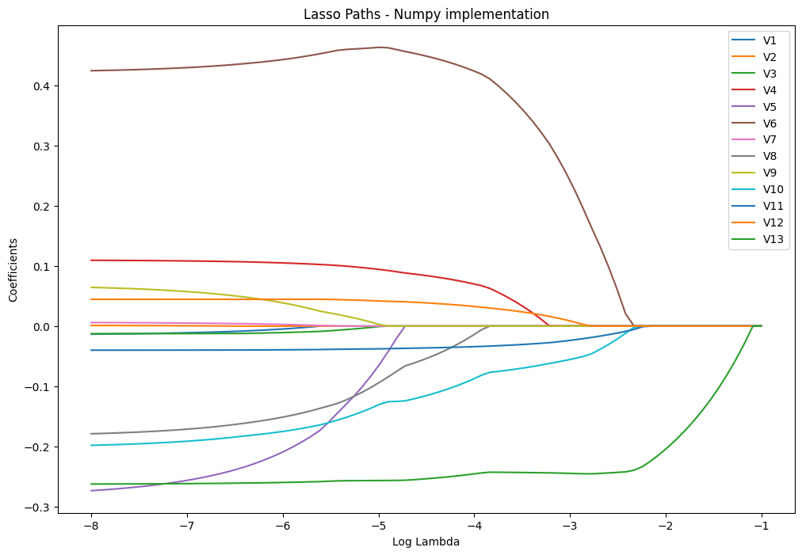

```python
p, _ = myout.shape
plt.figure(figsize = (12,8))

for i in range(p-1):
    plt.plot(log_lam_seq, myout[i+1, :], label = names[i])

plt.xlabel('Log Lambda')
plt.ylabel('Coefficients')
plt.title('Lasso Paths - Numpy implementation')
plt.legend()
plt.axis('tight')
```

```python
lasso_coef = pd.read_csv("Coding2_lasso_coefs.csv").to_numpy()
lasso_coef.shape
```

```
(14, 80)
```

```python
abs(myout - lasso_coef).max()
```

```
0.0046453174159237776
```

```python
abs(myout - lasso_coef).max() < 0.05
```

```
True
```

#### Part II: Simulation Study

Consider the following six procedures:

##### Full: Fit a linear regression model using all features

##### Ridge.min : Ridge regression using lambda.min

##### Lasso.min and Lasso.1se: Lasso using lambda.min or lambda.1se

##### L.Refit: Refit the model selected by Lasso using lambda.1se

##### PCR: principle components regression with the number of components chosen by 10-fold cross validation

#### Case I

Download the data set Coding2_Data1.csv. The first 14 columns are the same as the data set we used in Part I with Y being the response variable (moved to the 1st column). The additional 78 more predictors are the quadratic and pairwise product terms of the original 13 predictors.

[a] Conduct the following simulation exercise 50 times: In each iteration, randomly split the data into two parts, 75% for training and 25% for testing. For each of the six procedures, train a model using the training subset and generate predictions

for the test subset. Record the MSPE (Mean Squared Prediction Error) based on these test data predictions.

```python
url = "Coding2_Data1.csv"
myData = pd.read_csv(url)
Y = myData['Y']
X = myData.drop(['Y'], axis = 1)
X.shape, len(Y)
myData
```

|  | Y | V1 | V2 | V3 | V4 | V5 | V6 | V7 | V8 | V9 | ... | V82 | V83 | V84 | V85 | V86 | V87 | V88 | V89 | V90 | V91 |
| --- | --- | --- | --- | --- | --- | --- | --- | --- | --- | --- | --- | --- | --- | --- | --- | --- | --- | --- | --- | --- | --- |
| 0 | 3.178054 | -5.064036 | 1.8 | 0.837248 | 0 | -0.619897 | 1.883275 | 3.432567 | 1.408545 | 0.000000 | ... | 0.000000 | 0.000000 | 0.000000 | 0.000000 | 2.588344 | 22.585037 | 12.698557 | 1.805358 | 1.015072 | 8.857186 |
| 1 | 3.072693 | -3.600502 | 0.0 | 1.955860 | 0 | -0.757153 | 1.859574 | 5.529585 | 1.602836 | 0.693147 | ... | 3.804642 | 0.857042 | 2.751101 | 2.095553 | 6.786799 | 21.785594 | 16.594394 | 4.907472 | 3.738090 | 11.999253 |
| 2 | 3.546740 | -3.601235 | 0.0 | 1.955860 | 0 | -0.757153 | 1.971996 | 2.918119 | 1.602836 | 0.693147 | ... | 3.804642 | 0.857042 | 2.722890 | 1.391483 | 6.786799 | 21.562194 | 11.018966 | 4.857148 | 2.482157 | 7.886007 |
| 3 | 3.508556 | -3.430523 | 0.0 | 0.779325 | 0 | -0.780886 | 1.945624 | 1.419592 | 1.802073 | 1.098612 | ... | 5.935448 | 1.947005 | 4.335454 | 1.883728 | 9.574845 | 21.320586 | 9.263662 | 6.993794 | 3.038760 | 6.766495 |
| 4 | 3.589059 | -2.672924 | 0.0 | 0.779325 | 0 | -0.780886 | 1.966693 | 2.162710 | 1.802073 | 1.098612 | ... | 5.935448 | 1.947005 | 4.360392 | 2.536343 | 9.574845 | 21.443227 | 12.473049 | 7.034024 | 4.091536 | 9.163148 |
| ... | ... | ... | ... | ... | ... | ... | ... | ... | ... | ... | ... | ... | ... | ... | ... | ... | ... | ... | ... | ... | ... |
| 501 | 3.109061 | -2.770511 | 0.0 | 2.479056 | 0 | -0.556870 | 1.886008 | 3.969128 | 0.907694 | 0.000000 | ... | 0.000000 | 0.000000 | 0.000000 | 0.000000 | 24.945695 | 21.988568 | 17.443563 | 17.432057 | 13.828876 | 12.189565 |
| 502 | 3.025291 | -3.095111 | 0.0 | 2.479056 | 0 | -0.556870 | 1.811562 | 5.152149 | 0.827460 | 0.000000 | ... | 0.000000 | 0.000000 | 0.000000 | 0.000000 | 24.945695 | 22.263994 | 16.903043 | 17.650408 | 13.400363 | 11.959803 |
| 503 | 3.173878 | -2.800824 | 0.0 | 2.479056 | 0 | -0.556870 | 1.942476 | 7.899571 | 0.773574 | 0.000000 | ... | 0.000000 | 0.000000 | 0.000000 | 0.000000 | 24.945695 | 22.263994 | 13.321757 | 17.650408 | 10.561198 | 9.425853 |
| 504 | 3.091042 | -2.211009 | 0.0 | 2.479056 | 0 | -0.556870 | 1.916040 | 7.535788 | 0.870833 | 0.000000 | ... | 0.000000 | 0.000000 | 0.000000 | 0.000000 | 24.945695 | 22.070467 | 14.279384 | 17.496984 | 11.320384 | 10.015602 |
| 505 | 2.476538 | -3.048922 | 0.0 | 2.479056 | 0 | -0.556870 | 1.796747 | 5.868517 | 0.918289 | 0.000000 | ... | 0.000000 | 0.000000 | 0.000000 | 0.000000 | 24.945695 | 22.263994 | 15.746538 | 17.650408 | 12.483511 | 11.141514 |

506 rows × 92 columns

```python
def preprocess_data(X,Y):

    n = len(Y)
    indices = np.arange(0, n)
    np.random.shuffle(indices)
    test_ind = indices[:int(np.floor(0.25*n))]
    train_ind = indices[:int(np.floor(0.75*n))]

    # Splitting the data into training and testing sets
    X_train = X.iloc[train_ind]
    Y_train = Y[train_ind]
    X_test = X.iloc[test_ind]
    Y_test = Y[test_ind]

    # Create a StandardScaler instance and fit it on the training data,
    # Transform the training data using the fitted scaler and transform the test data using the same scaler

    scaler = StandardScaler()
    scaler.fit(X_train)

    X_train_scaled = scaler.transform(X_train)
    X_test_scaled = scaler.transform(X_test)

    return X_train,Y_train, X_test, Y_test, X_train_scaled, X_test_scaled
```

```python
n = len(Y)
indices = np.arange(0, n)
np.random.shuffle(indices)
test_ind = indices[:int(np.floor(0.25*n))]
train_ind = indices[len(test_ind):]

# Splitting the data into training and testing sets
X_train = X.iloc[train_ind]
Y_train = Y[train_ind]
X_test = X.iloc[test_ind]
Y_test = Y[test_ind]
```

```python
scaler = StandardScaler()
scaler.fit(X_train)

X_train_scaled = scaler.transform(X_train)
X_test_scaled = scaler.transform(X_test)
```

#### Full Model

```python
def full_lm(X_train,Y_train,X_test,Y_test):

    full = lm().fit(X_train, Y_train)
    full_mse_error = mean_squared_error(Y_test, full.predict(X_test))

    return full_mse_error
```

#### Ridge Regression

```python
def Ridge_Regression(X_train_scaled,X_test_scaled,Y_train,Y_test):

    ridge_alphas = np.logspace(-10, 1, 100)
    ridgecv = RidgeCV(alphas = ridge_alphas, cv = 10,
                      scoring = 'neg_mean_squared_error')
    ridgecv.fit(X_train_scaled, Y_train)
    ridgecv.alpha_

    ridge_model = Ridge(alpha = ridgecv.alpha_)
    ridge_model.fit(X_train_scaled, Y_train)
    mean_squared_error(Y_test, ridge_model.predict(X_test))

    Ridge_mse_err = mean_squared_error(Y_test, ridge_model.predict(X_test_scaled))

    return Ridge_mse_err
```

#### Ridge Regression - Scaled

```python
ridge_scaled_alphas = np.logspace(-10, 1, 100)
ridge_scaled_ridgecv = RidgeCV(alphas = ridge_scaled_alphas, cv = 10,
                  scoring = 'neg_mean_squared_error')
ridge_scaled_ridgecv.fit(X_train_scaled, Y_train)
ridge_scaled_ridgecv.alpha_
```

```
1.0
```

```python
ridge_scaled_model = Ridge(alpha = ridge_scaled_ridgecv.alpha_)
ridge_scaled_model.fit(X_train_scaled, Y_train)
mean_squared_error(Y_test, ridge_scaled_model.predict(X_test_scaled))
```

```
0.026280162308116434
```

#### Lasso

```python
def lasso(X_train_scaled,X_test_scaled,Y_train,Y_test):

    lasso_alphas = np.logspace(-10, 1, 100)
    lassocv = LassoCV(alphas = lasso_alphas, cv = 10)
    lassocv.fit(X_train_scaled, Y_train)

    mean_mse = np.mean(lassocv.mse_path_, axis=1)
    std_mse = np.std(lassocv.mse_path_, axis=1) / np.sqrt(10)

    cv_alphas = lassocv.alphas_
    min_idx = np.argmin(mean_mse)

    alpha_min = cv_alphas[min_idx]

    threshold = mean_mse[min_idx] + std_mse[min_idx]
    alpha_1se = max(cv_alphas[np.where(mean_mse <= threshold)])

    #### alpha_min
    lasso_model_min = Lasso(alpha = alpha_min, max_iter=10000)
    lasso_model_min.fit(X_train_scaled, Y_train)
    alpha_min_mse_err = mean_squared_error(Y_test, lasso_model_min.predict(X_test_scaled))

    #### alpha_1se
    lasso_model_1se = Lasso(alpha = alpha_1se, max_iter=10000)
    lasso_model_1se.fit(X_train_scaled, Y_train)
    alpha_1se_mse_err = mean_squared_error(Y_test, lasso_model_1se.predict(X_test_scaled))

    return alpha_min_mse_err,alpha_1se_mse_err, lasso_model_1se
```

```python
def Refit_lasso(lasso_model_1se,X_train,Y_train,X_test,Y_test):
    nonzero_indices = np.where(lasso_model_1se.coef_ != 0)[0]
    lm_refit = lm()
    lm_refit.fit(X_train.iloc[:, nonzero_indices], Y_train)
    refit_1m_mse_err = mean_squared_error(Y_test, lm_refit.predict(X_test.iloc[:, nonzero_indices]))

    return refit_1m_mse_err
```

#### PCR

```python
class PCR(object):

    def __init__(self, num_folds=10):
        self.folds = num_folds

    def fit(self, X, Y):
        n, p = X.shape
        indices = np.arange(n)
        np.random.shuffle(indices)
        index_sets = np.array_split(indices, self.folds)
        ncomp = min(p, n - 1 - max([len(i) for i in index_sets]))
        cv_err = np.zeros(ncomp)

        for ifold in range(self.folds):
            train_inds =  np.delete(index_sets, obj=ifold, axis=0).ravel()
            test_inds = index_sets[ifold]

            X_train = X[train_inds, :]
            pipeline = Pipeline([('scaling', StandardScaler()), ('pca', PCA())])
            pipeline.fit(X_train)
            X_train = pipeline.transform(X_train)
            coefs = Y[train_inds].T @ X_train / np.sum(X_train**2, axis=0)
            b0 = np.mean(Y[train_inds])

            X_test = pipeline.transform(X[test_inds, :])

            for k in np.arange(ncomp):
                preds = X_test[:, :k] @ coefs.T[:k] + b0
                cv_err[k] += cv_err[k] + np.sum((Y[test_inds]-preds)**2)

        min_ind = np.argmin(cv_err)
        self.ncomp = min_ind+1
        pipeline = Pipeline([('scaling', StandardScaler()), ('pca', PCA(n_components=self.ncomp))])
        self.transform = pipeline.fit(X)
        self.model = lm().fit(self.transform.transform(X), Y)

    def predict(self, X):
        X_ = self.transform.transform(X)
        return self.model.predict(X_)
```

```python
pcr = PCR()
pcr.fit(X_train.to_numpy(), Y_train.to_numpy())
# PCR_mse_err = mean_squared_error(Y_test, pcr.predict(X_test.to_numpy()))
# MSPE1[i,5] = PCR_mse_err
mean_squared_error(Y_test, pcr.predict(X_test.to_numpy()))
```

```
0.029236579736855176
```

```python
def simulate(X, Y):
    n = len(Y)
    indices = np.arange(0, n)
    np.random.shuffle(indices)
    test_ind = indices[:int(np.floor(0.25*n))]
    train_ind = indices[len(test_ind):]

    # Splitting the data into training and testing sets
    X_train = X.iloc[train_ind]
    Y_train = Y[train_ind]
    X_test = X.iloc[test_ind]
    Y_test = Y[test_ind]

    # Full Model
    full = lm().fit(X_train, Y_train)
    full_mse_error = mean_squared_error(Y_test, full.predict(X_test))

    #Ridge
    ridge_alphas = np.logspace(-10, 1, 100)
    ridgecv = RidgeCV(alphas = ridge_alphas, cv = 10, scoring = 'neg_mean_squared_error')
    ridgecv.fit(X_train, Y_train)
    ridgecv.alpha_

    ridge_model = Ridge(alpha = ridgecv.alpha_)
    ridge_model.fit(X_train, Y_train)
    ridge_mse_error = mean_squared_error(Y_test, ridge_model.predict(X_test))

    #Lasso
    lasso_alphas = np.logspace(-10, 1, 100)
    lassocv = LassoCV(alphas = lasso_alphas, cv = 10)
    lassocv.fit(X_train, Y_train)
    lassocv.alpha_

    mean_mse = np.mean(lassocv.mse_path_, axis=1)
    std_mse = np.std(lassocv.mse_path_, axis=1) / np.sqrt(10)

    cv_alphas = lassocv.alphas_
    min_idx = np.argmin(mean_mse)

    alpha_min = cv_alphas[min_idx]

    threshold = mean_mse[min_idx] + std_mse[min_idx]
    alpha_1se = max(cv_alphas[np.where(mean_mse <= threshold)])

    alpha_min, alpha_1se  #alpha_min = lassocv.alpha_

    #Lasso with alpha_min
    lasso_model_min = Lasso(alpha = alpha_min, max_iter=10000)
    lasso_model_min.fit(X_train, Y_train)
    lasso_alpha_min_mse_error = mean_squared_error(Y_test, lasso_model_min.predict(X_test))

    #Lasso with alpha_1se
    lasso_model_1se = Lasso(alpha = alpha_1se, max_iter=10000)
    lasso_model_1se.fit(X_train, Y_train)
    lasso_alpha_1se_mse_error = mean_squared_error(Y_test, lasso_model_1se.predict(X_test))

    #Refit with alpha_1se
    nonzero_indices = np.where(lasso_model_1se.coef_ != 0)[0]
    lm_refit = lm()
    lm_refit.fit(X_train.iloc[:, nonzero_indices], Y_train)
    lm_refit_mse_error = mean_squared_error(Y_test, lm_refit.predict(X_test.iloc[:, nonzero_indices]))

    #PCR
    pcr = PCR()
    pcr.fit(X_train.to_numpy(), Y_train.to_numpy())
    pcr_mse_error = mean_squared_error(Y_test, pcr.predict(X_test.to_numpy()))

    return np.array([full_mse_error, ridge_mse_error, lasso_alpha_min_mse_error, lasso_alpha_1se_mse_error, lm_refit_mse_error, pcr_mse_error])
```

```python
simulation_count = 50

MSPE1 = np.zeros((simulation_count, 6))

for i in range(simulation_count):
    print("Simulation:", i)
    MSPE1[i] = simulate(X, Y)
```

[output not shown]

[b] Graphically summarize your findings on the MSPE using a strip chart, and consider overlaying a boxplot for additional insights.

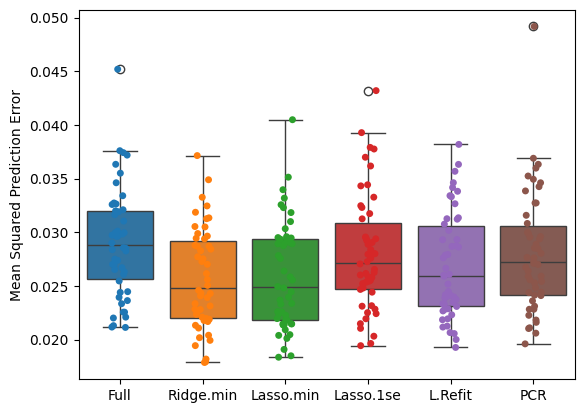

```python
# [b] Graphically summarize findings on the MSPE using a strip chart with a boxplot overlay.

fig, ax = plt.subplots()

bp1 = sns.boxplot(data=MSPE1)
g1 = sns.stripplot(data=MSPE1, ax=ax)

xtick_labels = np.array(["Full", "Ridge.min", "Lasso.min", "Lasso.1se", "L.Refit", "PCR"])
g1.set_xticks(range(xtick_labels.shape[0]), xtick_labels)
ax.set_ylabel('Mean Squared Prediction Error')


plt.show()
```

##### Which procedure or procedures yield the best performance in terms of MSPE?

Response: Lasso.min and Ridge.min, because majority of dots are placed within boundary, in addition, in comparison of Lasso.min, its MSPE medians is the lowest.

##### Conversely, which procedure or procedures show the poorest performance?

Response: PCR, its MSPE medians is the highest, except "Full" model.

##### In the context of Lasso regression, which procedure, Lasso.min or Lasso.1se, yields a better MSPE?

Response: Lasso.min, because its dots are placed much more intensive than the other, in addition, MSPE medians of Lasso.min is lower than that of Lasso.1se.

##### Is refitting advantageous in this case? In other words, does L.Refit outperform Lasso.1se?

Response: Yes. Its MSPE medians is lower than that of Lasso.1se.

##### Is variable selection or shrinkage warranted for this particular dataset? To clarify, do you find the performance of the Full model to be comparable to, or divergent from, the best-performing procedure among the other five?

Response: According to diagram above, Full model has the highest MSPE medians. To reply this question, it's less effective than the others.

#### Case II

Download the data set Coding2_Data2.csv. The first 92 columns are identical to those in Coding2_Data1.csv, with the addition of 500 columns of artificially generated noise features.

Repeat [a] and [b] above for the five procedures excluding the Full procedure. Graphically summarize your findings on MSPE using a strip chart, and consider overlaying a boxplot for additional insights.

```python
url = "Coding2_Data2.csv"
myData = pd.read_csv(url)
Y2 = myData['Y']
X2 = myData.drop(['Y'], axis = 1)
X2.shape, len(Y2)
myData
```

|  | Y | V1 | V2 | V3 | V4 | V5 | V6 | V7 | V8 | V9 | ... | N491 | N492 | N493 | N494 | N495 | N496 | N497 | N498 | N499 | N500 |
| --- | --- | --- | --- | --- | --- | --- | --- | --- | --- | --- | --- | --- | --- | --- | --- | --- | --- | --- | --- | --- | --- |
| 0 | 3.178054 | -5.064036 | 1.8 | 0.837248 | 0 | -0.619897 | 1.883275 | 3.432567 | 1.408545 | 0.000000 | ... | 9.311734 | 42.340409 | -98.237024 | -0.218876 | 242.378197 | 22.914414 | 2.833203 | -0.731567 | 188.338755 | 5.603043 |
| 1 | 3.072693 | -3.600502 | 0.0 | 1.955860 | 0 | -0.757153 | 1.859574 | 5.529585 | 1.602836 | 0.693147 | ... | 2.483401 | 42.541682 | -78.161235 | 0.006359 | 230.500638 | 21.378003 | 7.343570 | -0.772128 | 54.120184 | 12.177419 |
| 2 | 3.546740 | -3.601235 | 0.0 | 1.955860 | 0 | -0.757153 | 1.971996 | 2.918119 | 1.602836 | 0.693147 | ... | 2.194146 | 42.293921 | -147.972805 | -0.090360 | 242.084995 | 21.058327 | 3.806554 | -1.270361 | 44.435169 | 9.204234 |
| 3 | 3.508556 | -3.430523 | 0.0 | 0.779325 | 0 | -0.780886 | 1.945624 | 1.419592 | 1.802073 | 1.098612 | ... | 1.380064 | 42.239553 | -98.077415 | -0.123421 | 238.506944 | 22.806647 | 2.727724 | -0.899344 | 25.356220 | 4.598476 |
| 4 | 3.589059 | -2.672924 | 0.0 | 0.779325 | 0 | -0.780886 | 1.966693 | 2.162710 | 1.802073 | 1.098612 | ... | 5.271136 | 42.241969 | -114.842999 | 0.213375 | 228.014166 | 21.363451 | 1.084881 | -1.203496 | 135.781350 | 1.796305 |
| ... | ... | ... | ... | ... | ... | ... | ... | ... | ... | ... | ... | ... | ... | ... | ... | ... | ... | ... | ... | ... | ... |
| 501 | 3.109061 | -2.770511 | 0.0 | 2.479056 | 0 | -0.556870 | 1.886008 | 3.969128 | 0.907694 | 0.000000 | ... | 9.289245 | 42.071578 | -225.068718 | -0.576334 | 274.251058 | 25.768029 | 10.401569 | -1.281458 | 136.433781 | 18.718453 |
| 502 | 3.025291 | -3.095111 | 0.0 | 2.479056 | 0 | -0.556870 | 1.811562 | 5.152149 | 0.827460 | 0.000000 | ... | 9.389476 | 42.211936 | -225.987858 | -0.272054 | 274.185485 | 25.568916 | 9.561055 | -1.247076 | 136.281498 | 15.663172 |
| 503 | 3.173878 | -2.800824 | 0.0 | 2.479056 | 0 | -0.556870 | 1.942476 | 7.899571 | 0.773574 | 0.000000 | ... | 9.111879 | 42.052610 | -225.396912 | -0.175229 | 274.875859 | 25.641045 | 10.279514 | -1.333198 | 136.385232 | 17.333334 |
| 504 | 3.091042 | -2.211009 | 0.0 | 2.479056 | 0 | -0.556870 | 1.916040 | 7.535788 | 0.870833 | 0.000000 | ... | 4.977584 | 42.052857 | -127.474806 | -0.017724 | 252.254905 | 23.219008 | 3.557936 | -0.961842 | 91.511589 | 6.519813 |
| 505 | 2.476538 | -3.048922 | 0.0 | 2.479056 | 0 | -0.556870 | 1.796747 | 5.868517 | 0.918289 | 0.000000 | ... | 5.241037 | 41.862826 | -114.408289 | 0.461174 | 238.700733 | 22.878130 | 1.832253 | -1.128218 | 107.415070 | 3.021066 |

506 rows × 592 columns

```python
n = len(Y)
indices = np.arange(0, n)
np.random.shuffle(indices)
test_ind = indices[:int(np.floor(0.25*n))]
train_ind = indices[len(test_ind):]

# Splitting the data into training and testing sets
X_train = X.iloc[train_ind]
Y_train = Y[train_ind]
X_test = X.iloc[test_ind]
Y_test = Y[test_ind]
```

```python
scaler = StandardScaler()
scaler.fit(X_train)

X_train_scaled = scaler.transform(X_train)
X_test_scaled = scaler.transform(X_test)
```

```python
full = lm().fit(X_train, Y_train)
mean_squared_error(Y_test, full.predict(X_test))
```

```
0.02668463894221487
```

```python
# ridge_alphas = np.logspace(-10, 1, 100)
# ridgecv = RidgeCV(alphas = ridge_alphas, cv = 10,
#                   scoring = 'neg_mean_squared_error')
# ridgecv.fit(X_train, Y_train)
# ridgecv.alpha_

# ridge_model = Ridge(alpha = ridgecv.alpha_, normalize=True)
# ridge_model.fit(X_train, Y_train)
# mean_squared_error(Y_test, ridge_model.predict(X_test))
```

```python
ridge_scaled_alphas = np.logspace(-10, 1, 100)
ridge_scaled_ridgecv = RidgeCV(alphas = ridge_scaled_alphas, cv = 10,
                  scoring = 'neg_mean_squared_error')
ridge_scaled_ridgecv.fit(X_train_scaled, Y_train)
ridge_scaled_ridgecv.alpha_
```

```
2.782559402207126
```

```python
ridge_scaled_model = Ridge(alpha = ridge_scaled_ridgecv.alpha_)
ridge_scaled_model.fit(X_train_scaled, Y_train)
mean_squared_error(Y_test, ridge_scaled_model.predict(X_test_scaled))
```

```
0.018053074904320274
```

```python
np.logspace(0, 3, num=5)
```

```
array([   1.        ,    5.62341325,   31.6227766 ,  177.827941  ,
       1000.        ])
```

```python
lasso_alphas = np.logspace(-10, 1, 100)
lassocv = LassoCV(alphas = lasso_alphas, cv = 10)
lassocv.fit(X_train, Y_train)
lassocv.alpha_
```

```
0.003593813663804626
```

```python
mean_mse = np.mean(lassocv.mse_path_, axis=1)
std_mse = np.std(lassocv.mse_path_, axis=1) / np.sqrt(10)

cv_alphas = lassocv.alphas_
min_idx = np.argmin(mean_mse)

alpha_min = cv_alphas[min_idx]

threshold = mean_mse[min_idx] + std_mse[min_idx]
alpha_1se = max(cv_alphas[np.where(mean_mse <= threshold)])

alpha_min, alpha_1se
```

```
(0.003593813663804626, 0.007742636826811262)
```

```python
lasso_model_min = Lasso(alpha = alpha_min, max_iter=10000)
lasso_model_min.fit(X_train, Y_train)
mean_squared_error(Y_test, lasso_model_min.predict(X_test))
```

```
0.018398748561845864
```

```python
lasso_model_1se = Lasso(alpha = alpha_1se, max_iter=10000)
lasso_model_1se.fit(X_train, Y_train)
mean_squared_error(Y_test, lasso_model_1se.predict(X_test))
```

```
0.021915707719380326
```

```python
nonzero_indices = np.where(lasso_model_1se.coef_ != 0)[0]
lm_refit = lm()
lm_refit.fit(X_train.iloc[:, nonzero_indices], Y_train)
mean_squared_error(Y_test, lm_refit.predict(X_test.iloc[:, nonzero_indices]))
```

```
0.01916847454693104
```

```python
class PCR(object):

    def __init__(self, num_folds=10):
        self.folds = num_folds

    def fit(self, X, Y):
        n, p = X.shape
        indices = np.arange(n)
        np.random.shuffle(indices)
        index_sets = np.array_split(indices, self.folds)
        ncomp = min(p, n - 1 - max([len(i) for i in index_sets]))
        cv_err = np.zeros(ncomp)

        for ifold in range(self.folds):
            train_inds =  np.delete(index_sets, obj=ifold, axis=0).ravel()
            test_inds = index_sets[ifold]

            X_train = X[train_inds, :]
            pipeline = Pipeline([('scaling', StandardScaler()), ('pca', PCA())])
            pipeline.fit(X_train)
            X_train = pipeline.transform(X_train)
            coefs = Y[train_inds].T @ X_train / np.sum(X_train**2, axis=0)
            b0 = np.mean(Y[train_inds])

            X_test = pipeline.transform(X[test_inds, :])

            for k in np.arange(ncomp):
                preds = X_test[:, :k] @ coefs.T[:k] + b0
                cv_err[k] += cv_err[k] + np.sum((Y[test_inds]-preds)**2)

        min_ind = np.argmin(cv_err)
        self.ncomp = min_ind+1
        pipeline = Pipeline([('scaling', StandardScaler()), ('pca', PCA(n_components=self.ncomp))])
        self.transform = pipeline.fit(X)
        self.model = lm().fit(self.transform.transform(X), Y)

    def predict(self, X):
        X_ = self.transform.transform(X)
        return self.model.predict(X_)
```

```python
pcr = PCR()
pcr.fit(X_train.to_numpy(), Y_train.to_numpy())
mean_squared_error(Y_test, pcr.predict(X_test.to_numpy()))
```

```
0.018751841602468282
```

```python
def simulate_2(X, Y):
    n = len(Y)
    indices = np.arange(0, n)
    np.random.shuffle(indices)
    test_ind = indices[:int(np.floor(0.25*n))]
    train_ind = indices[len(test_ind):]

    # Splitting the data into training and testing sets
    X_train = X.iloc[train_ind]
    Y_train = Y[train_ind]
    X_test = X.iloc[test_ind]
    Y_test = Y[test_ind]

    #Ridge
    ridge_alphas = np.logspace(-10, 1, 100)
    ridgecv = RidgeCV(alphas = ridge_alphas, cv = 10, scoring = 'neg_mean_squared_error')
    ridgecv.fit(X_train, Y_train)
    ridgecv.alpha_

    ridge_model = Ridge(alpha = ridgecv.alpha_)
    ridge_model.fit(X_train, Y_train)
    ridge_mse_error = mean_squared_error(Y_test, ridge_model.predict(X_test))

    #Lasso
    lasso_alphas = np.logspace(-10, 1, 100)
    lassocv = LassoCV(alphas = lasso_alphas, cv = 10)
    lassocv.fit(X_train, Y_train)
    lassocv.alpha_

    mean_mse = np.mean(lassocv.mse_path_, axis=1)
    std_mse = np.std(lassocv.mse_path_, axis=1) / np.sqrt(10)

    cv_alphas = lassocv.alphas_
    min_idx = np.argmin(mean_mse)

    alpha_min = cv_alphas[min_idx]

    threshold = mean_mse[min_idx] + std_mse[min_idx]
    alpha_1se = max(cv_alphas[np.where(mean_mse <= threshold)])

    alpha_min, alpha_1se  #alpha_min = lassocv.alpha_

    #Lasso with alpha_min
    lasso_model_min = Lasso(alpha = alpha_min, max_iter=10000)
    lasso_model_min.fit(X_train, Y_train)
    lasso_alpha_min_mse_error = mean_squared_error(Y_test, lasso_model_min.predict(X_test))

    #Lasso with alpha_1se
    lasso_model_1se = Lasso(alpha = alpha_1se, max_iter=10000)
    lasso_model_1se.fit(X_train, Y_train)
    lasso_alpha_1se_mse_error = mean_squared_error(Y_test, lasso_model_1se.predict(X_test))

    #Refit with alpha_1se
    nonzero_indices = np.where(lasso_model_1se.coef_ != 0)[0]
    lm_refit = lm()
    lm_refit.fit(X_train.iloc[:, nonzero_indices], Y_train)
    lm_refit_mse_error = mean_squared_error(Y_test, lm_refit.predict(X_test.iloc[:, nonzero_indices]))

    #PCR
    pcr = PCR()
    pcr.fit(X_train.to_numpy(), Y_train.to_numpy())
    pcr_mse_error = mean_squared_error(Y_test, pcr.predict(X_test.to_numpy()))

    return np.array([ridge_mse_error, lasso_alpha_min_mse_error, lasso_alpha_1se_mse_error, lm_refit_mse_error, pcr_mse_error])
```

```python
simulation_count = 50

MSPE2 = np.zeros((simulation_count, 5))

for i in range(simulation_count):
    print("Simulation:", i)
    MSPE2[i] = simulate_2(X, Y)
```

[output not shown]

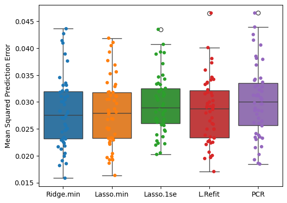

```python
fig, ax = plt.subplots()

bp1 = sns.boxplot(data=MSPE2)
g1 = sns.stripplot(data=MSPE2, ax=ax)

xtick_labels = np.array(["Ridge.min", "Lasso.min", "Lasso.1se", "L.Refit", "PCR"])
g1.set_xticks(range(xtick_labels.shape[0]), xtick_labels)
ax.set_ylabel('Mean Squared Prediction Error')
plt.show()
```